# Как тип задания влияет на посещение форума

## 1. Об отчете

### Исследовательские вопросы

1. Как тип заданий влияет на количество посещенных страниц форума при выполнении задания?
2. Как тип заданий влияет на посещение форума при выполнении задания?
3. Как тип заданий влияет на долю посещений форума при взаимодействии с заданием?

### Описание баз данных и ее переменных

```r
wd <- getwd()
assignments <- fread("unzip -cq ../data/assignments.zip") %>% mutate(vis_tw_b = ifelse(vis_tw==0, 0, 1), vis_before_attempt_tw_b = ifelse(vis_before_attempt_tw==0, 0, 1)) %>%  mutate(course_item_type_desc = factor(course_item_type_desc))
```

#### Количество курсов в анализе

```r
length(unique(assignments$course_name))
```

```
## [1] 49
```

#### Количество парных курсов

```r
tw_paired<- assignments  %>% group_by(course_name) %>% filter(assessment_status == 1) %>%
  mutate(n = n_distinct(course_item_type_desc)) %>% filter(n == 2)

length(unique(tw_paired$course_name))
```

```
## [1] 10
```

### Переменные

- **attempts** - Попытки за задание. Сколько попыток этот студент сделал при решении этого задания;
- **vis_tw** - Число посещенных страниц форума. Сколько раз этот студент посещал форум во время прохождения этого задания;
- **vis_tw_b** - Посещение форума. Посещал ли студент форум хотя бы раз;
- **rate** - Доля посещений форума. Какая часть из студенто-заданий на данном курсе побудила студентов зайти на форум.
  - студенто-задание - взаимодействие одного студента с одним заданием.
  - rate = число студенто-заданий, во время решения которых студент зашел на форум / число студенто-заданий на курсе.
  - например: 1 - все задания побудили всех студентов зайти на форум, 0 - ни одно задание не побудило ни одного студента зайти на форум.
- **assessment_id** - токен задания;
- **hse_user_id** - токен студента;
- **course_item_type_desc** - тип задания;
  - *lecture* - тест в видео (исключаю из анализа);
  - *test* - тест;
  - *programming* - задание по программированию;

## 0. Descriptive statistics

Распределение заданий:

```r
table(assignments$course_item_type_desc)
```

```
##
## programming        quiz
##      778577      479813
```

Распределение посещений форума:

```r
table(assignments$vis_tw_b, assignments$course_item_type_desc)
```

```
##
##     programming   quiz
##   0      516233 443373
##   1      262344  36440
```

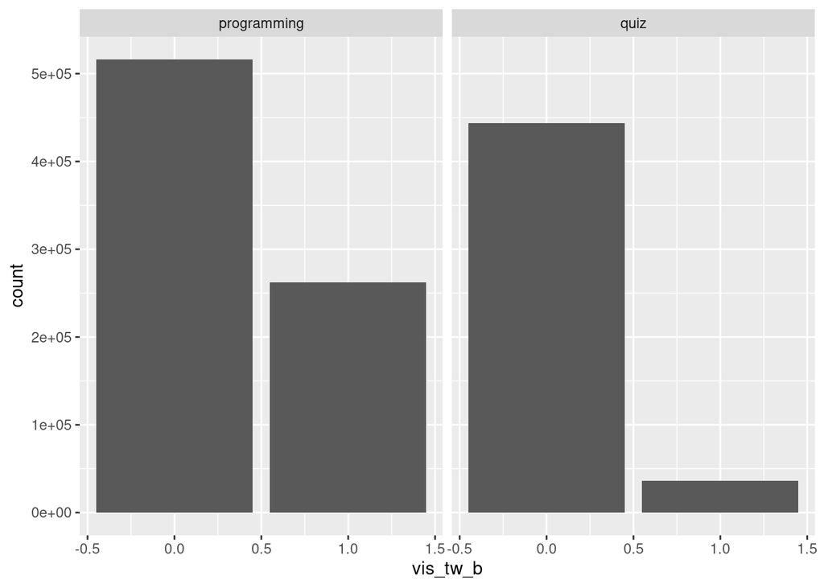

```r
assignments %>%  ggplot(aes(x = vis_tw_b)) + geom_histogram(stat="count")+ facet_wrap(~course_item_type_desc)
```

Для наглядности сравним два распределения: посещение форума во время взаимодействия с заданием и до первой попытки.

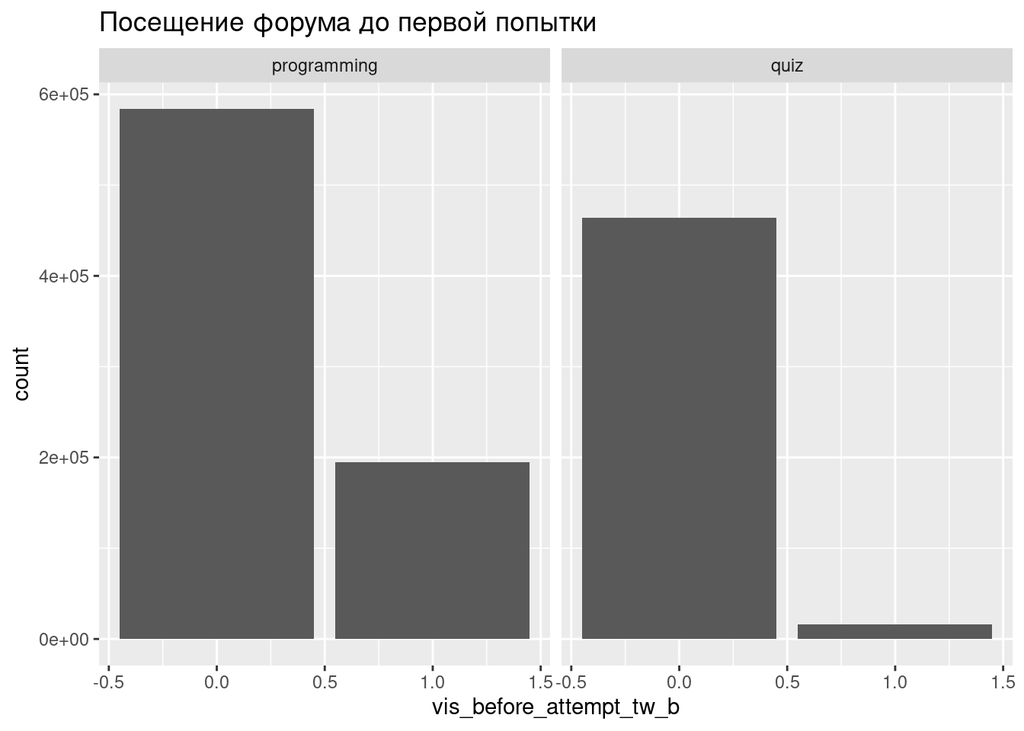

```r
assignments %>%  ggplot(aes(x = vis_before_attempt_tw_b)) + geom_histogram(stat="count")+ facet_wrap(~course_item_type_desc) + ggtitle('Посещение форума до первой попытки')
```

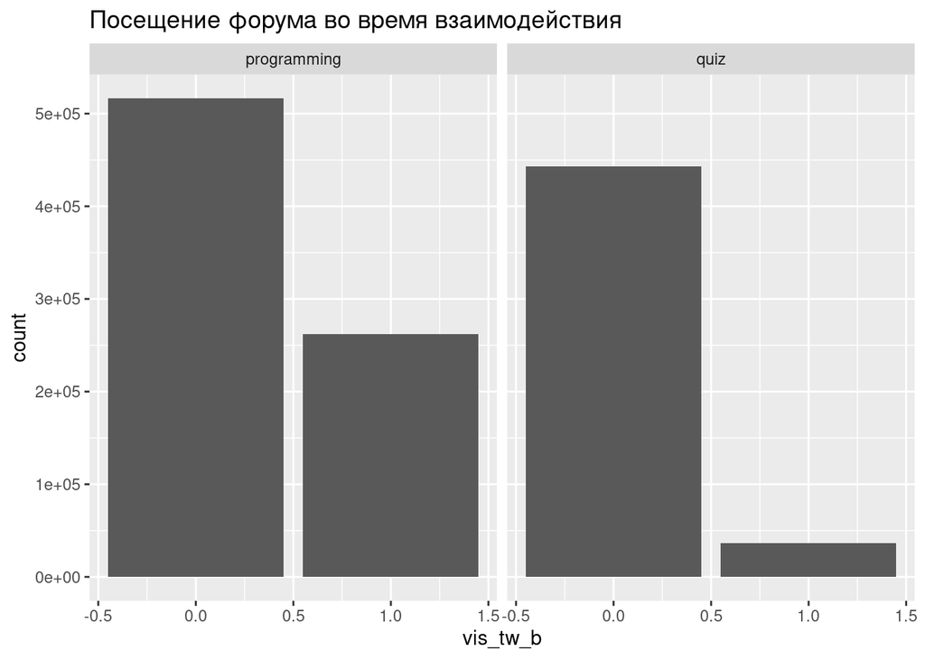

```r
assignments %>%  ggplot(aes(x = vis_tw_b)) + geom_histogram(stat="count")+ facet_wrap(~course_item_type_desc) + ggtitle('Посещение форума во время взаимодействия')
```

Видим, что за все время форум посещало больше людей, что логично. Также видим, что число посещений для задний по программированию заметно увеличилось.

Распределение посещений страниц:

```r
summary(assignments$vis_tw)
```

```
##     Min.  1st Qu.   Median     Mean  3rd Qu.     Max.
##    0.000    0.000    0.000    7.124    0.000 6132.000
```

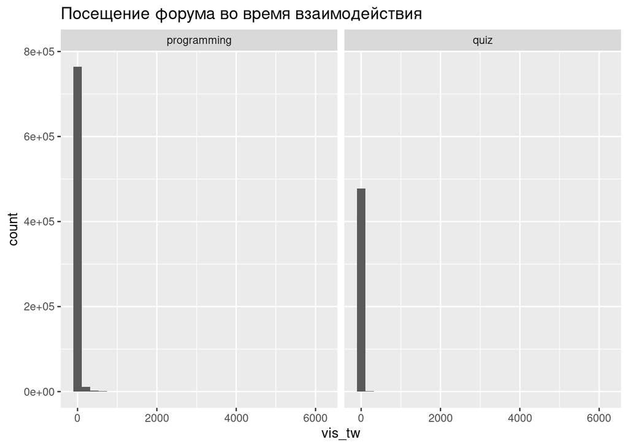

```r
#hist(assignments$vis_tw, breaks = 500, xlim = range(0, 500))
assignments %>%  ggplot(aes(x = vis_tw)) + geom_histogram(stat="bin")+ facet_wrap(~course_item_type_desc) + ggtitle('Посещение форума во время взаимодействия')
```

# 1. Анализ вариации посещений

```r
m0 <- glmer(factor(vis_tw_b) ~ 1 + (1|course_name),
            family = binomial,
            assignments)
summary(m0)
```

```
## Generalized linear mixed model fit by maximum likelihood (Laplace
##   Approximation) [glmerMod]
##  Family: binomial  ( logit )
## Formula: factor(vis_tw_b) ~ 1 + (1 | course_name)
##    Data: assignments
##
##       AIC       BIC    logLik  deviance  df.resid
## 1244537.9 1244562.0 -622266.9 1244533.9   1258388
##
## Scaled residuals:
##     Min      1Q  Median      3Q     Max
## -1.0830 -0.6981 -0.3226 -0.1136  9.9995
##
## Random effects:
##  Groups      Name        Variance Std.Dev.
##  course_name (Intercept) 1.29     1.136
## Number of obs: 1258390, groups:  course_name, 49
##
## Fixed effects:
##             Estimate Std. Error z value Pr(>|z|)
## (Intercept) -2.16265    0.02281  -94.83   <2e-16 ***
## ---
## Signif. codes:  0 '***' 0.001 '**' 0.01 '*' 0.05 '.' 0.1 ' ' 1
```

```
## Вероятность посещения форума на среднем курсе равна 0.10.
```

```
## Эта вероятность будет колебаться между: 0.04 и 0.25.
```

```r
m1 <- glmer(factor(vis_tw_b) ~ 1 + course_item_type_desc  + (1|course_name),
            family = binomial,
            assignments)
summary(m1)
```

```
## Generalized linear mixed model fit by maximum likelihood (Laplace
##   Approximation) [glmerMod]
##  Family: binomial  ( logit )
## Formula: factor(vis_tw_b) ~ 1 + course_item_type_desc + (1 | course_name)
##    Data: assignments
##
##       AIC       BIC    logLik  deviance  df.resid
## 1223300.8 1223337.0 -611647.4 1223294.8   1258387
##
## Scaled residuals:
##     Min      1Q  Median      3Q     Max
## -1.5365 -0.6981 -0.3226 -0.1136  9.8874
##
## Random effects:
##  Groups      Name        Variance Std.Dev.
##  course_name (Intercept) 0.9104   0.9541
## Number of obs: 1258390, groups:  course_name, 49
##
## Fixed effects:
##                           Estimate Std. Error z value Pr(>|z|)
## (Intercept)               -0.55227    0.03626  -15.23   <2e-16 ***
## course_item_type_descquiz -1.83626    0.01241 -147.98   <2e-16 ***
## ---
## Signif. codes:  0 '***' 0.001 '**' 0.01 '*' 0.05 '.' 0.1 ' ' 1
##
## Correlation of Fixed Effects:
##             (Intr)
## crs_tm_typ_ -0.005
## convergence code: 0
## Model failed to converge with max|grad| = 0.00271382 (tol = 0.002, component 1)
```

```
##
## Вероятность, посещения форума на курсе с программированием: 0.36
```

```
## Вероятность, посещения форума на курсе  без программирования: 0.08
```

```
## Эта вероятность будет колебаться между: 0.03 и 0.19.
```

# 2. Анализ вариации посещенных страниц

```r
m0 <- glmer(vis_tw ~ 1 + (1|course_name),
            family = "poisson",
            assignments)
dispersion_glmer(m0)
```

```
## [1] 5.914003
```

```r
m0 <- glmer.nb(vis_tw ~ 1 + (1|course_name),
            assignments)
dispersion_glmer(m0)
```

```
## [1] 0.705912
```

```r
summary(m0)
```

```
## Generalized linear mixed model fit by maximum likelihood (Laplace
##   Approximation) [glmerMod]
##  Family: Negative Binomial(0.0659)  ( log )
## Formula: vis_tw ~ 1 + (1 | course_name)
##    Data: assignments
##
##      AIC      BIC   logLik deviance df.resid
##  3738744  3738780 -1869369  3738738  1258387
##
## Scaled residuals:
##     Min      1Q  Median      3Q     Max
##  -0.256  -0.256  -0.253  -0.204 241.003
##
## Random effects:
##  Groups      Name        Variance Std.Dev.
##  course_name (Intercept) 2.8      1.673
## Number of obs: 1258390, groups:  course_name, 49
##
## Fixed effects:
##             Estimate Std. Error z value Pr(>|z|)
## (Intercept)   0.2266     0.0166   13.65   <2e-16 ***
## ---
## Signif. codes:  0 '***' 0.001 '**' 0.01 '*' 0.05 '.' 0.1 ' ' 1
## convergence code: 0
## Model failed to converge with max|grad| = 0.00416735 (tol = 0.002, component 1)
```

```
## Количество посещенных страниц форума на среднем курсе равна 1.25.
```

[output not shown]

```r
m1 <- glmer.nb(vis_tw ~ 1 + course_item_type_desc  + (1|course_name),
            assignments)
summary(m1)
```

```
## Generalized linear mixed model fit by maximum likelihood (Laplace
##   Approximation) [glmerMod]
##  Family: Negative Binomial(0.067)  ( log )
## Formula: vis_tw ~ 1 + course_item_type_desc + (1 | course_name)
##    Data: assignments
##
##      AIC      BIC   logLik deviance df.resid
##  3731093  3731141 -1865542  3731085  1258386
##
## Scaled residuals:
##     Min      1Q  Median      3Q     Max
##  -0.259  -0.258  -0.252  -0.206 242.890
##
## Random effects:
##  Groups      Name        Variance Std.Dev.
##  course_name (Intercept) 2.313    1.521
## Number of obs: 1258390, groups:  course_name, 49
##
## Fixed effects:
##                           Estimate Std. Error z value Pr(>|z|)
## (Intercept)                1.55541    0.01990   78.16   <2e-16 ***
## course_item_type_descquiz -1.53354    0.01666  -92.08   <2e-16 ***
## ---
## Signif. codes:  0 '***' 0.001 '**' 0.01 '*' 0.05 '.' 0.1 ' ' 1
##
## Correlation of Fixed Effects:
##             (Intr)
## crs_tm_typ_ 0.062
## convergence code: 0
## Model failed to converge with max|grad| = 0.00472798 (tol = 0.002, component 1)
```

```
## Количество посещенных страниц форума на курсе с программированием: 4.74
```

```
## Количество посещенных страниц на курсе без программирования: 1.02
```

```
## Это количество будет колебаться между: 0.22 и 4.68.
```